# Analysing and Visualising the Dataset of Techno Film from Super8database

In this notebook I will analyza a simple dataset I downloaded from Super8database.org to visualize some of the genres that have been distributed by the Italian distributor Techno Film during the 70s and 80s. The company sold material not only in Italy, but also in Europe, in Spain or in the Netherlands. They were so widespread that some of those small gauge films are very easy to find even today on ebay.

```python
#download the packages for doing an and visualizations
import numpy as np
import pandas as pd
import matplotlib.pyplot as plt
```

```python
#reading dataset with pandas, overview of the table content
technofilm_df = pd.read_csv('distributortechno_film.csv',na_values=[0], delimiter=",")
```

```python
technofilm_df.head() #first look at the dataset
```

|  | id | distributor | catalog_number | title | reels | color | sound | year | description | tags | people | imdb_code | runtime |
| --- | --- | --- | --- | --- | --- | --- | --- | --- | --- | --- | --- | --- | --- |
| 0 | 4517 | Techno Film | YS 158 | 14 Carrot Rabbit | 200 | color | sound | 1952.0 | When Yosemite Sam realizes that he can make hi... | Bugs Bunny, Cartoon | Friz Freleng, Mel Blanc | tt0044313 | 07:00 |
| 1 | 2255 | Techno Film | NaN | 2000 Feet to Die | 300 | color | sound | 1972.0 | An early episode of "The Protectors" TV series... | Adventure, Crime, The Protectors | Robert Vaughn, Nyree Dawn Porter, Tony Anholt | tt0679975 | NaN |
| 2 | 4813 | Techno Film | SIL 628 | A Bird In A Bonnet | 200 | color | sound | 1958.0 | NaN | Tweety, Cartoon, Sylvester | NaN | tt0051414 | NaN |
| 3 | 3933 | Techno Film | FL 54 | A Broken Leghorn | 200 | color | sound | 1959.0 | NaN | Foghorn Leghorn, Cartoon | NaN | tt0052651 | NaN |
| 4 | 9068 | Techno Film | 1265 | A Grape is Bom | 200 | color | sound | NaN | NaN | Cartoon, The Great Grape Ape | Bob Holt, Marty Ingels | tt5998984 | NaN |

```python
#counting rows

rows_number = len(technofilm_df.index)
print("The dataset has " + str(rows_number) + " rows")
```

```
The dataset has 111 rows
```

```python
#which data types I have
display(technofilm_df.dtypes)
```

```
id                  int64
distributor        object
catalog_number     object
title              object
reels              object
color              object
sound              object
year              float64
description        object
tags               object
people             object
imdb_code          object
runtime            object
dtype: object
```

The year is a float, so it didn´t recognize it. Now I change it into an integer

```python
technofilm_df['year'] = technofilm_df['year'].fillna(0).astype(int)
```

```python
#which data types I have
display(technofilm_df.dtypes)
```

```
id                 int64
distributor       object
catalog_number    object
title             object
reels             object
color             object
sound             object
year               int64
description       object
tags              object
people            object
imdb_code         object
runtime           object
dtype: object
```

```python
technofilm_df.head() #second look at the dataset
```

|  | id | distributor | catalog_number | title | reels | color | sound | year | description | tags | people | imdb_code | runtime |
| --- | --- | --- | --- | --- | --- | --- | --- | --- | --- | --- | --- | --- | --- |
| 0 | 4517 | Techno Film | YS 158 | 14 Carrot Rabbit | 200 | color | sound | 1952 | When Yosemite Sam realizes that he can make hi... | Bugs Bunny, Cartoon | Friz Freleng, Mel Blanc | tt0044313 | 07:00 |
| 1 | 2255 | Techno Film | NaN | 2000 Feet to Die | 300 | color | sound | 1972 | An early episode of "The Protectors" TV series... | Adventure, Crime, The Protectors | Robert Vaughn, Nyree Dawn Porter, Tony Anholt | tt0679975 | NaN |
| 2 | 4813 | Techno Film | SIL 628 | A Bird In A Bonnet | 200 | color | sound | 1958 | NaN | Tweety, Cartoon, Sylvester | NaN | tt0051414 | NaN |
| 3 | 3933 | Techno Film | FL 54 | A Broken Leghorn | 200 | color | sound | 1959 | NaN | Foghorn Leghorn, Cartoon | NaN | tt0052651 | NaN |
| 4 | 9068 | Techno Film | 1265 | A Grape is Bom | 200 | color | sound | 0 | NaN | Cartoon, The Great Grape Ape | Bob Holt, Marty Ingels | tt5998984 | NaN |

I ask Chatgpt for help with this prompt: In my dataset there is a column named tag, in those cells there are too many values. I want to group the values and add a column named "genre" where all the rows that have in their tag cell at least once "cartoon" they can be labeled in the genre column only with that value. Same thing for the tag cell which has at least once "documentary", or for "sci-fi", or for "western" or "adventure/action"

```python
import pandas as pd
import numpy as np

# Your DataFrame is assumed to be already loaded
# technofilm_df = pd.read_csv("yourfile.csv")  # or however you loaded it

# Define the function
def assign_genre(tags):
    if pd.isnull(tags):
        return np.nan  # or "Unknown"
    tags = tags.lower()  # lowercase everything
    if "cartoon" in tags:
        return "cartoon"
    elif "documentary" in tags:
        return "documentary"
    elif "sci-fi" in tags:
        return "sci-fi"
    elif "western" in tags:
        return "western"
    elif "adventure" in tags:
        return "adventure/action"
    elif "action" in tags:
        return "adventure/action"
    elif "drama" in tags:
        return "drama"
    else:
        return "Others"

# Apply the function
technofilm_df['genre'] = technofilm_df['tags'].apply(assign_genre)
```

```python
technofilm_df.head() #third look at the dataset
```

|  | id | distributor | catalog_number | title | reels | color | sound | year | description | tags | people | imdb_code | runtime | genre |
| --- | --- | --- | --- | --- | --- | --- | --- | --- | --- | --- | --- | --- | --- | --- |
| 0 | 4517 | Techno Film | YS 158 | 14 Carrot Rabbit | 200 | color | sound | 1952 | When Yosemite Sam realizes that he can make hi... | Bugs Bunny, Cartoon | Friz Freleng, Mel Blanc | tt0044313 | 07:00 | cartoon |
| 1 | 2255 | Techno Film | NaN | 2000 Feet to Die | 300 | color | sound | 1972 | An early episode of "The Protectors" TV series... | Adventure, Crime, The Protectors | Robert Vaughn, Nyree Dawn Porter, Tony Anholt | tt0679975 | NaN | adventure/action |
| 2 | 4813 | Techno Film | SIL 628 | A Bird In A Bonnet | 200 | color | sound | 1958 | NaN | Tweety, Cartoon, Sylvester | NaN | tt0051414 | NaN | cartoon |
| 3 | 3933 | Techno Film | FL 54 | A Broken Leghorn | 200 | color | sound | 1959 | NaN | Foghorn Leghorn, Cartoon | NaN | tt0052651 | NaN | cartoon |
| 4 | 9068 | Techno Film | 1265 | A Grape is Bom | 200 | color | sound | 0 | NaN | Cartoon, The Great Grape Ape | Bob Holt, Marty Ingels | tt5998984 | NaN | cartoon |

Let's see also what is in my dataset. As you may see many statistical values cannot be counted since most of data entries in my datasets are strings.

```python
technofilm_df.describe(include='all')
```

|  | id | distributor | catalog_number | title | reels | color | sound | year | description | tags | people | imdb_code | runtime | genre |
| --- | --- | --- | --- | --- | --- | --- | --- | --- | --- | --- | --- | --- | --- | --- |
| count | 111.000000 | 111 | 80 | 111 | 111 | 111 | 111 | 111.000000 | 25 | 111 | 80 | 85 | 4 | 111 |
| unique | NaN | 1 | 77 | 107 | 6 | 2 | 2 | NaN | 25 | 42 | 56 | 76 | 4 | 7 |
| top | NaN | Techno Film | 1010 | Det Mystiska Huset | 200 | color | sound | NaN | When Yosemite Sam realizes that he can make hi... | Scooby Doo, Cartoon | Chuck Jones | tt0907034 | 07:00 | cartoon |
| freq | NaN | 111 | 2 | 2 | 82 | 101 | 93 | NaN | 1 | 11 | 6 | 4 | 1 | 73 |
| mean | 5050.585586 | NaN | NaN | NaN | NaN | NaN | NaN | 1326.918919 | NaN | NaN | NaN | NaN | NaN | NaN |
| std | 3172.988633 | NaN | NaN | NaN | NaN | NaN | NaN | 923.510980 | NaN | NaN | NaN | NaN | NaN | NaN |
| min | 698.000000 | NaN | NaN | NaN | NaN | NaN | NaN | 0.000000 | NaN | NaN | NaN | NaN | NaN | NaN |
| 25% | 1728.500000 | NaN | NaN | NaN | NaN | NaN | NaN | 0.000000 | NaN | NaN | NaN | NaN | NaN | NaN |
| 50% | 5120.000000 | NaN | NaN | NaN | NaN | NaN | NaN | 1957.000000 | NaN | NaN | NaN | NaN | NaN | NaN |
| 75% | 8696.500000 | NaN | NaN | NaN | NaN | NaN | NaN | 1970.000000 | NaN | NaN | NaN | NaN | NaN | NaN |
| max | 9315.000000 | NaN | NaN | NaN | NaN | NaN | NaN | 1978.000000 | NaN | NaN | NaN | NaN | NaN | NaN |

Now I want to visualize the frequency of certain genres within my film dataset. First I need to count how many times certain genres (as strings) are showing in my dataset

```python
#Titles per genres


# Get count duplicates single column using dataframe.pivot_table()
genres_df = technofilm_df.pivot_table(index = ['genre'], aggfunc ='size')
print(genres_df)
```

```
genre
Others              11
adventure/action     5
cartoon             73
documentary          8
drama                4
sci-fi               7
western              3
dtype: int64
```

Counting the frequency of genre

```python
#counting the frequency of genre per film

genre_list = pd.DataFrame(technofilm_df.genre.value_counts())
genre_list["Frequency"] = technofilm_df.genre.value_counts(normalize=True)
genre_list = genre_list.reset_index()
genre_list = genre_list.rename(columns = {"index": "genre", "count": "Number of Films"})
genre_list.loc[genre_list.Frequency < 0.03, 'genre'] = 'Others'
genre_list = (genre_list
                .groupby('genre').sum()
                .sort_values('Number of Films', ascending=False)
                .reset_index())
print(genre_list)
```

```
              genre  Number of Films  Frequency
0           cartoon               73   0.657658
1            Others               14   0.126126
2       documentary                8   0.072072
3            sci-fi                7   0.063063
4  adventure/action                5   0.045045
5             drama                4   0.036036
```

Now I want to visualize the frequency of genre in the dataset with a Pie chart

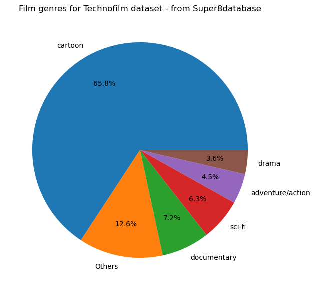

```python
#pie chart
import seaborn as sns

plt.figure(figsize=(9, 7))
plt.pie(genre_list["Number of Films"], labels = genre_list["genre"], autopct='%1.1f%%', pctdistance=0.7)
sns.color_palette("tab20")
plt.title("Film genres for Technofilm dataset - from Super8database")
plt.savefig("Technofilm_Genres_Pie.jpg", dpi=250, bbox_inches='tight')
```